# Parameters for caracterising plant, air, food, time and workers in meat facilities

ANR SACADA

02/02/2022

## 0.2 Parameters of interest

### 0.2.1 Parameters associated to plant

*The parameter relative to the plant will be entered in the file : parameters_plant.R*

- Cutting Room (it is the main room of the plant)
- Entry hall
- Waste area
- W.C.
- Cooling area
- Office
- Arrival gate

Each room needs to be positioned on the entire workshop grid. The cutting room is the main build by substracting all other rooms. The position of the door is also mentioned with four variables : “top,” “bottom,” “left” or “right.”

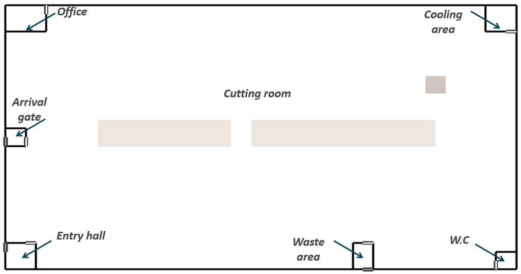

Figure 1 : Plan of the processing plant

Table 1. Set of parameters for charateryzing the room in the plant. The cutting room is built by subtracting the other room

[output not shown]

For this purpose each room has to be defined. Two elements are taken into account

- the dimensions of the rooms: length, width and height
- the parameters related to the ventilation of the room

The kind of ventilation type could be :

- Controlled Mecanical Ventilation [CMV]
- Direct Expansion Coil [DEC]
- Air Handing Unit [AHU]

Table 2. Set of parameters used for charateryzing the plant.

[output not shown]

### 0.2.2 Parameters associated to differnts objets in the plant

The objects must be defined. They are positioned in the model on the X and Y axis, together with the dimensions.

We have implemented two types of objects: two conveyors, that allows the pieces of meat to be transported from one point to another, and an equipment that can be shared by several operators, such as a peeler.

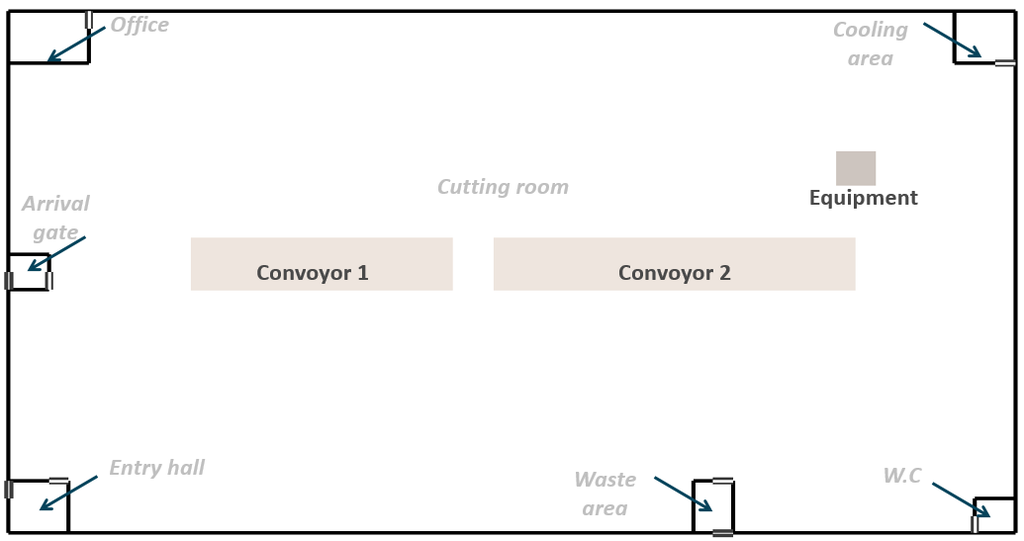

Figure 2 : Plan of the processing plant with object

Table 3. Set of parameters for charateryzing the different object in the plant.

| Parameters | name of the object | length of the object | width of the object | Position of regarding the X axis of the plant | Position regarding the Y axis of the plant |
| --- | --- | --- | --- | --- | --- |
| Label in ABM script | label | dim.X | dim.Y | pos.X | pos.Y |
| unit |  | meter | meter | 0 to 1 (0: left, 0.5: middle, 1:right) | 0 to 1 (0: bottom, 0.5: middle, 1:top) |
| cvy | Conveyor1 | 13 | 3 | 0.2 | 0.5 |
| cvy2 | Conveyor2 | 18 | 3 | 0.5 | 0.5 |
| epmA | Equipment 1 | 2 | 2 | 0.85 | 0.7 |

### 0.2.3 Parameters associated to worker

*The parameter relative to the simulation time will be entered in the file : parameters_workers.R*

The operators are differentiated according to their functions

- Cutter 1 : deboning or cutting carcasses into large pieces
- Cutter 2 : cutting large pieces into small pieces
- Logistic 1 : bringing the carcasses to the cutters
- Logistic 2 : recover cut products then pack and store
- Transverse 1: manager / chief / maintenance staff who come to the workshop a few times a day
- Transverse 2: people from the cleaning team

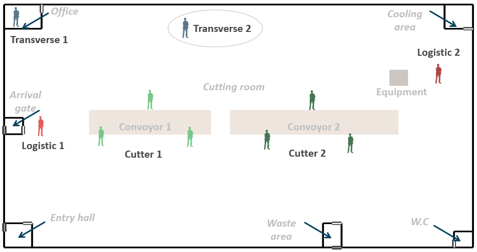

Figure 3 : Plan of the processing plant with worker

The number of employees is defined as follows.

Table 3. Set of parameters used for charateryzing the worker of the plant.

| Parameters | Label in ABM script | Value | Unit | Uncertainty range | References |
| --- | --- | --- | --- | --- | --- |
| Total number of worker | Nworkers | 100.000 | N/A | [??-??] | [interviews] |
| Number of regular worker | Nworkers_ext | 15.000 | N/A | [1-4] | [interviews] |
| Number of temporary worker |  | NA |  |  |  |
| Number of subcontract worker |  | NA |  |  |  |
| *Overall proportion for different types of workers* |  |  |  |  |  |
| Cutter | cutter1 | 0.360 | ratio (0 to 1) | [5-11] | (Mallet et al. 2021) |
| Cutter | cutter2 | 0.470 | ratio (0 to 1) | [5-11] | (Mallet et al. 2021) |
| Logistic | logistic1 | 0.040 | ratio (0 to 1) |  | (Gunther et al. 2020) |
| Logistic | logistic2 | 0.040 | ratio (0 to 1) |  | (Gunther et al. 2020) |
| Transverse | transverse1 | 0.045 | ratio (0 to 1) | [0.18-0.475] | (Mallet et al. 2021) |
| Transverse | transverse2 | 0.045 | ratio (0 to 1) |  | (Mallet et al. 2021) |

NWorkers not yet used

#### 0.2.3.1 Parameters will be may be implemented

Worker types with important mission having high probabilities to be present at work despite their possible contamination/symptoms –> mandatoryWorkersType = c(“transverse1”)

### 0.2.6 Parameters relative to the simulation time.

*The parameter relative to the simulation time will be entered in the file : parameters_time.R*

It consists in filling two parameters:

- the total duration that will be simulated (“NDays” in the ABM, in days), for example, 365 days;
- the simulated time interval of the simulation (“Step” in the ABM, in minutes), for example 5 minutes.

## References

Gunther, T., M. Czech-Sioli, D. Indenbirken, A. Robitaille, P. Tenhaken, M. Exner, M. Ottinger, N. Fischer, A. Grundhoff, and M. M. Brinkmann. 2020. “SARS-CoV-2 Outbreak Investigation in a German Meat Processing Plant.” Journal Article. *EMBO Mol Med* 12 (12): e13296. https://doi.org/10.15252/emmm.202013296.

Mallet, Yoann, Mathilde Pivette, Matthieu Revest, Elisabeth Angot, Marion Valence, Clarisse Dupin, Nicolas Picard, et al. 2021. “Identification of Workers at Increased Risk of Infection During a COVID-19 Outbreak in a Meat Processing Plant, France, May 2020.” Journal Article. *Food and Environmental Virology*, 1–9. https://doi.org/10.1007/s12560-021-09500-1.